# ImplementCNN

## Training a Convolutional Neural Network Using Keras

A very common problem in computer vision is recognizing hand-written digits. The images of numerals are commonly used by data scientists and machine learning experts to train supervised learning models that specialize in decoding human handwriting. This is a classic problem that is often used in exercises and documentation. In this demo, we will show you how to train a convolutional neural network to classify hand-written digits using Keras in TensorFlow.

**Note: some of the code cells in this notebook may take a while to run**

### Import Packages

To get started, let us import Keras, along with other libraries.

```python
import os
os.environ["TF_CPP_MIN_LOG_LEVEL"] = "2" # suppress info and warning messages
import tensorflow.keras as keras
import math
import time
import numpy as np
import seaborn as sns
import matplotlib.pyplot as plt
%matplotlib inline
```

### Define the ML Problem

We will implement a convolutional neural network to solve a handwriting recognition problem. The neural network will classify a hand-written digit.

#### Define the Label

We will work with the MNIST data set, a famous collection of images used for handwriting recognition. It contains labeled images of handwritten digits from 0 to 9. Therefore, the label is a digit from 0 and 9. This is a multiclass classification problem.

#### Identify Features

Each example corresponds to one hand-written image. The features will be comprised of numerical feature vectors (an n-dimensional array) that contain grey-scale pixel values that range from 0 to 255.

### Import the Data Set and Create Training and Test Sets

The MNIST data set comes preloaded in Keras. The `load_data()` function returns the data set split into training and test subsets. The cell below loads the data set and contains training and test data.

```python
# The mnist data set comes preloaded
mnist = keras.datasets.mnist

# Create training and test sets
(X_train, y_train),(X_test, y_test) = mnist.load_data()
```

```
Downloading data from https://storage.googleapis.com/tensorflow/tf-keras-datasets/mnist.npz
```

#### Inspect the Data

The code cell below displays the datatype and dimensions (shape) of the training and test data.

```python
print(X_train.shape)
print(type(X_train))
print(y_train.shape)
print(type(y_train))
print(X_test.shape)
print(type(X_test))
print(y_test.shape)
print(type(y_test))
```

```
(60000, 28, 28)
<class 'numpy.ndarray'>
(60000,)
<class 'numpy.ndarray'>
(10000, 28, 28)
<class 'numpy.ndarray'>
(10000,)
<class 'numpy.ndarray'>
```

Notice that the training and test data sets are NumPy arrays.

Let's take a look at the data in more detail. Let's inspect the first example (which contains an image) in `X_train`:

```python
X_train[0].shape
```

```
(28, 28)
```

```python
X_train[0]
```

```
array([[  0,   0,   0,   0,   0,   0,   0,   0,   0,   0,   0,   0,   0,
          0,   0,   0,   0,   0,   0,   0,   0,   0,   0,   0,   0,   0,
          0,   0],
       [  0,   0,   0,   0,   0,   0,   0,   0,   0,   0,   0,   0,   0,
          0,   0,   0,   0,   0,   0,   0,   0,   0,   0,   0,   0,   0,
          0,   0],
       [  0,   0,   0,   0,   0,   0,   0,   0,   0,   0,   0,   0,   0,
          0,   0,   0,   0,   0,   0,   0,   0,   0,   0,   0,   0,   0,
          0,   0],
       [  0,   0,   0,   0,   0,   0,   0,   0,   0,   0,   0,   0,   0,
          0,   0,   0,   0,   0,   0,   0,   0,   0,   0,   0,   0,   0,
          0,   0],
       [  0,   0,   0,   0,   0,   0,   0,   0,   0,   0,   0,   0,   0,
          0,   0,   0,   0,   0,   0,   0,   0,   0,   0,   0,   0,   0,
          0,   0],
       [  0,   0,   0,   0,   0,   0,   0,   0,   0,   0,   0,   0,   3,
         18,  18,  18, 126, 136, 175,  26, 166, 255, 247, 127,   0,   0,
          0,   0],
       [  0,   0,   0,   0,   0,   0,   0,   0,  30,  36,  94, 154, 170,
        253, 253, 253, 253, 253, 225, 172, 253, 242, 195,  64,   0,   0,
          0,   0],
       [  0,   0,   0,   0,   0,   0,   0,  49, 238, 253, 253, 253, 253,
        253, 253, 253, 253, 251,  93,  82,  82,  56,  39,   0,   0,   0,
          0,   0],
       [  0,   0,   0,   0,   0,   0,   0,  18, 219, 253, 253, 253, 253,
        253, 198, 182, 247, 241,   0,   0,   0,   0,   0,   0,   0,   0,
          0,   0],
       [  0,   0,   0,   0,   0,   0,   0,   0,  80, 156, 107, 253, 253,
        205,  11,   0,  43, 154,   0,   0,   0,   0,   0,   0,   0,   0,
          0,   0],
       [  0,   0,   0,   0,   0,   0,   0,   0,   0,  14,   1, 154, 253,
         90,   0,   0,   0,   0,   0,   0,   0,   0,   0,   0,   0,   0,
          0,   0],
       [  0,   0,   0,   0,   0,   0,   0,   0,   0,   0,   0, 139, 253,
        190,   2,   0,   0,   0,   0,   0,   0,   0,   0,   0,   0,   0,
          0,   0],
       [  0,   0,   0,   0,   0,   0,   0,   0,   0,   0,   0,  11, 190,
        253,  70,   0,   0,   0,   0,   0,   0,   0,   0,   0,   0,   0,
          0,   0],
       [  0,   0,   0,   0,   0,   0,   0,   0,   0,   0,   0,   0,  35,
```

[output cut: 29 more lines]

```
       [  0,   0,   0,   0,  55, 172, 226, 253, 253, 253, 253, 244, 133,
         11,   0,   0,   0,   0,   0,   0,   0,   0,   0,   0,   0,   0,
          0,   0],
       [  0,   0,   0,   0, 136, 253, 253, 253, 212, 135, 132,  16,   0,
          0,   0,   0,   0,   0,   0,   0,   0,   0,   0,   0,   0,   0,
          0,   0],
       [  0,   0,   0,   0,   0,   0,   0,   0,   0,   0,   0,   0,   0,
          0,   0,   0,   0,   0,   0,   0,   0,   0,   0,   0,   0,   0,
          0,   0],
       [  0,   0,   0,   0,   0,   0,   0,   0,   0,   0,   0,   0,   0,
          0,   0,   0,   0,   0,   0,   0,   0,   0,   0,   0,   0,   0,
          0,   0],
       [  0,   0,   0,   0,   0,   0,   0,   0,   0,   0,   0,   0,   0,
          0,   0,   0,   0,   0,   0,   0,   0,   0,   0,   0,   0,   0,
          0,   0]], dtype=uint8)
```

As expected, the first example in the training data is a 28 x 28 array. This array encodes the grayscale value of the hand-written image, i.e., each entry in the 28 x 28 array encodes the intensity (darkness) of the corresponding pixel.

### Visualize the Data

The code cell below uses the Seaborn`heatmap()` function to display one image contained in `X_train`.

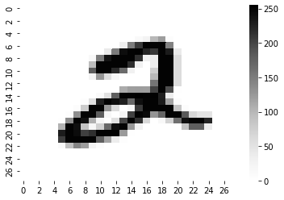

```python
sns.heatmap(X_train[5], cmap=plt.cm.Greys)
```

Let's inspect the corresponding label in `y_train` to confirm that the label matches the image you see in the heatmap above.

```python
y_train[5]
```

```
2
```

We've created a function `plot_imgs()` to help us visualize the image data. Let's use this function to inspect a few more examples in the training data. Execute the two code cells below.

```python
# Function to visualize the data
def plot_imgs(images, labels=None):
    subplots_x = int(math.ceil(len(images) / 5))
    plt.figure(figsize=(10,2*subplots_x))
    for i in range(min(len(images), subplots_x*5)):
        plt.subplot(subplots_x,5,i+1)
        plt.xticks([])
        plt.yticks([])
        plt.grid(False)
        plt.imshow(images[i], cmap=plt.cm.binary)
        if labels is not None:
            plt.xlabel(labels[i])
    plt.show()
```

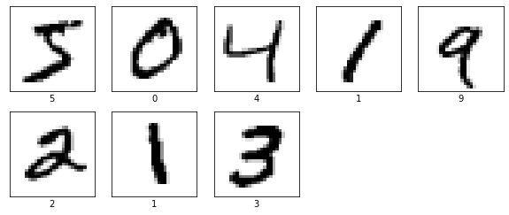

```python
# Visualize some training examples
plot_imgs(X_train[:8], y_train[:8])
```

### Prepare the Data

Let's now prepare our data to be suitable for a CNN.

#### Scale the Data

Our MNIST data is raw data containing pixel values between 0 and 255. Neural networks process inputs using small weight values, and inputs with large integer values can disrupt or slow down the training process. Therefore, it is a good practice to normalize the pixel values so that each pixel has a value between 0 and 1. This can be done by dividing all pixels values by the largest pixel value; that is 255.

The code cell below normalizes the pixel values in `X_train` and `X_test` to be between 0 and 1 by dividing all feature values by 255.0.

```python
X_train, X_test = X_train / 255.0, X_test / 255.0
```

#### Reshape the Data

A CNN in Keras requires a 4-dimensional array as input in the form: `(num_examples, image_dimension_X, image_dimension_Y, num_channels)`.

Since grayscale has only one color channel, every example in `X_train` would have the shape `(28, 28, 1)`. `X_test` should have the same dimensions.

The code cell below uses the NumPy `reshape()` function to:

1. reshape every example in `X_train` to have the shape `(num_examples_X_train, 28, 28, 1)`.
2. reshape every example in `X_test` to have the shape `(num_examples_X_test, 28, 28, 1)`.

```python
X_train = np.reshape(X_train, (X_train.shape[0], 28, 28, 1))
X_test = np.reshape(X_test, (X_test.shape[0], 28, 28, 1))
```

## Implement a Convolutional Neural Network

Recall that the steps to implement a network model using Keras are:

1. Construct the Neural Network:
   1. Define the model structure.
   2. Define the optimization algorithm, i.e., the variant of gradient descent you want to use.
   3. Define the loss function to minimize.
   4. Compile the model.
2. Train the neural network:  
   "Fit" the model to the training data for $M$ epochs.
3. Evaluate the model's performance.

We will follow these same steps to implement a convolutional neural network. We will walk you through these steps.

## Part 1. Construct the Convolutional Neural Network

### Step 1. Define Model Structure

We will create our convolutional neural network structure. A CNN typically contains three main types of layers: convolutional layers, pooling layers, and fully connected (dense) layers. When constructing a convolutional hidden layer, we will compose a 2D convolution, followed by a batch normalization, followed by an activation function.

- As before, we will use the Keras `Sequential` class to group a stack of layers. This will be our CNN model object. For more information, consult the Keras online [Sequential class documentation](https://keras.io/api/models/sequential/#sequential-class).

The code cell below creates the CNN structure (Note that there are different ways one can choose to construct a CNN in Keras). We will create an input layer, five hidden layers and an output layer:

- **Input layer**: The input layer will have the input shape corresponding to the number of features.
- **Hidden layers**: We will create five hidden layers:
  - Four hidden layers will be convolutional layers. They will be comprised of a 2D convolution, followed by a batch normalization, followed by an activation function. In this case, the activation function of choice is ReLU.
  - One hidden layer will be a pooling layer. We will add a layer that uses Global Average Pooling. This is a pooling operation designed to replace the final fully connected layer in classical CNN.
- **Output layer**: The output layer will have a width of 10.

```python
# Create CNN model object

cnn_model = keras.Sequential()

# Construct the input layer and add it to the model object:
input_layer = keras.layers.InputLayer(input_shape=(28, 28, 1))
cnn_model.add(input_layer)

# Construct the first convolutional layer and add it to the model object:
conv_1= keras.layers.Conv2D(16, 3)
batchNorm_1 =  keras.layers.BatchNormalization()
relu_1 = keras.layers.ReLU()
cnn_model.add(conv_1)
cnn_model.add(batchNorm_1)
cnn_model.add(relu_1)

# Construct the second convolutional layer and add it to the model object:
conv_2= keras.layers.Conv2D(32, 3)
batchNorm_2 =  keras.layers.BatchNormalization()
relu_2 = keras.layers.ReLU()
cnn_model.add(conv_2)
cnn_model.add(batchNorm_2)
cnn_model.add(relu_2)

#  Construct the third convolutional layer and add it to the model object:
conv_3= keras.layers.Conv2D(64, 3)
batchNorm_3 = keras.layers.BatchNormalization()
relu_3 = keras.layers.ReLU()
cnn_model.add(conv_3)
cnn_model.add(batchNorm_3)
cnn_model.add(relu_3)

# Construct the fourth convolutional layer and add it to the model object:
conv_4= keras.layers.Conv2D(128, 3)
batchNorm_4 =  keras.layers.BatchNormalization()
relu_4 = keras.layers.ReLU()
cnn_model.add(conv_4)
cnn_model.add(batchNorm_4)
cnn_model.add(relu_4)

# Construct the pooling layer and add it to the model object:
pooling_layer = keras.layers.GlobalAveragePooling2D()
cnn_model.add(pooling_layer)

# Construct the output layer and add it to the model object:
output_layer = keras.layers.Dense(units=10)
cnn_model.add(output_layer)

# Print model summary
cnn_model.summary()
```

```
Model: "sequential"
_________________________________________________________________
Layer (type)                 Output Shape              Param #
=================================================================
conv2d (Conv2D)              (None, 26, 26, 16)        160
_________________________________________________________________
batch_normalization (BatchNo (None, 26, 26, 16)        64
_________________________________________________________________
re_lu (ReLU)                 (None, 26, 26, 16)        0
_________________________________________________________________
conv2d_1 (Conv2D)            (None, 24, 24, 32)        4640
_________________________________________________________________
batch_normalization_1 (Batch (None, 24, 24, 32)        128
_________________________________________________________________
re_lu_1 (ReLU)               (None, 24, 24, 32)        0
_________________________________________________________________
conv2d_2 (Conv2D)            (None, 22, 22, 64)        18496
_________________________________________________________________
batch_normalization_2 (Batch (None, 22, 22, 64)        256
_________________________________________________________________
re_lu_2 (ReLU)               (None, 22, 22, 64)        0
_________________________________________________________________
conv2d_3 (Conv2D)            (None, 20, 20, 128)       73856
_________________________________________________________________
batch_normalization_3 (Batch (None, 20, 20, 128)       512
_________________________________________________________________
re_lu_3 (ReLU)               (None, 20, 20, 128)       0
_________________________________________________________________
global_average_pooling2d (Gl (None, 128)               0
_________________________________________________________________
dense (Dense)                (None, 10)                1290
=================================================================
Total params: 99,402
Trainable params: 98,922
Non-trainable params: 480
_________________________________________________________________
```

Let's break this down. Our network is comprised of an input layer, five hidden layers (four convolutional layers and a pooling layer) and an output layer.

**Input layer**

We passed the following arguments to the `keras.layers.InputLayer()` function:.

- `input_shape`: dimensionality of the input layer. In this case, the dimensions are the shape of each example (image) in `X_train`.

**Hidden layers**

- Convolutional layers:

  As stated above, when constructing a convolutional hidden layer, we composed a 2D convolution, followed by a batch normalization, followed by an activation function.
  1. 2D convolution:
     - We used the `Conv2D` class to create each convolutional layer. For more information, consult the Keras online [Conv2D class documentation](https://keras.io/api/layers/convolution_layers/convolution2d/). `Conv2D()` requires an argument specifying the number of convolutional filters in the layer. Layers closer to the input use fewer filters, while deeper layers use more filters to learn increasingly complex features.Therefore, we chose 16 filters for the first layer, 32 filters for the second layer, 64 filters for the third layer, and 128 filters for the fourth layer. Each layer uses a kernel size of 3, meaning each filter has a dimension of 3×3.
  1. Batch normalization:
     - Batch normalization is used to stabilize and speed up training by keeping the layer outputs on a consistent scale. For batch normalization, we used the `BatchNormalization` class. For more information, consult the Keras online [BatchNormalization class documentation](https://keras.io/api/layers/normalization_layers/batch_normalization/).
  2. Activation Function:
     - For the activation function, we used the `ReLU` class. For more information, consult the Keras online [ReLU class documentation](https://keras.io/api/layers/activation_layers/relu/).
- Pooling layer:
  - We used the `GlobalAveragePooling2D` class to create the pooling layer. For more information, consult the Keras online [GlobalAveragePooling2D class documentation](https://keras.io/api/layers/pooling_layers/global_average_pooling2d/).

**Output Layer**:

The output layer is a single dense layer. We will have one node per class. We have ten classes (digits from 0-9). Therefore, when creating the output later, we specified 10 units.

### Step 2. Define the Optimization Algorithm

As our optimizer we will use stochastic gradient descent (SGD) with a learning rate of 0.1.

```python
sgd_optimizer = keras.optimizers.SGD(learning_rate=0.1)
```

### Step 3. Define the Loss Function

Since we are working with a multi-class classification problem, we will use a sparse categorical cross entropy loss function using `keras.losses.SparseCategoricalCrossentropy()`. This is an extension of the categorical cross entropy loss function that is used when there are two or more label classes and the labels are integers. For more information, consult the online [SparseCategoricalCrossentropy documentation](https://www.tensorflow.org/api_docs/python/tf/keras/losses/SparseCategoricalCrossentropy).

```python
loss_fn = keras.losses.SparseCategoricalCrossentropy(from_logits=True)
```

### Step 4. Compile the Model

Now we will package the network architecture with the optimizer and the loss function using the `cnn_model.compile()` method. We will specify `accuracy`as the evaluation metric since we would like to obtain the accuracy score.

```python
cnn_model.compile(optimizer=sgd_optimizer, loss=loss_fn, metrics=['accuracy'])
```

## Part 5. Fit the Model to the Training Data

We can now fit the CNN model to the training data. Since there are 60,000 training examples and nearly 100,000 parameters to fit, this may take a while to run. Therefore, we will only choose one epoch.

**Note**: This may take a while to run.

```python
num_epochs = 1 # Number of epochs

t0 = time.time() # start time

history = cnn_model.fit(X_train, y_train, epochs=num_epochs)

t1 = time.time() # stop time

print('Elapsed time: %.2fs' % (t1-t0))
```

```
Elapsed time: 82.33s
```

## Part 6. Evaluate the Model's Performance

Let's now evaluate our CNN model's performance on our test data and see how it did.

The code cell below used the `cnn_model.evaluate()` method with the test data sets as arguments. The `evaluate()` method returns a list containing two values. The first value is the loss and the second value is the accuracy score.

```python
loss, accuracy = cnn_model.evaluate(X_test, y_test, verbose=0)

print('Loss: ', str(loss) , 'Accuracy: ', str(accuracy))
```

```
Loss:  0.30917418003082275 Accuracy:  0.897599995136261
```

Next we'll make some predictions on the test set and see for ourselves how accurate these predictions are.

The code cell below calls the `plot_imgs()` function defined above. The first argument is the first 25 images in `X_test`, and the second argument is the first 25 labels in `predictions`.

The result should be a display of the first 25 images in the test set `X_test`, and below each image, a display of the predicted digit. How well did we do?

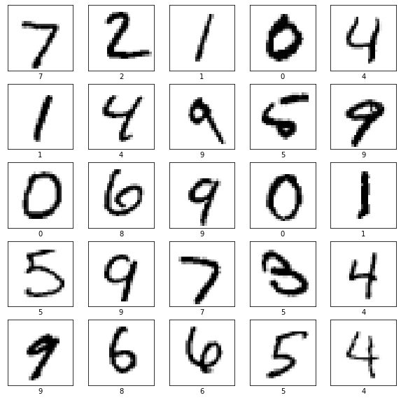

```python
# Make predictions on the test set
logits = cnn_model.predict(X_test)
predictions = logits.argmax(axis = 1)

## Plot individual predictions
plot_imgs(X_test[:25], predictions[:25])
```